# How accurate can Central Limit Theorem approximate?

Yan Shen

11/10/2019

# I. Introduction

> **Central limit theorem** can be an short-cut to computation for sampling distribution of the mean, given the conditions are satisfied:
> 1. Independent observations
> 2. Identically distributed observations
> 3. Mean and variance exist
> 4. Sample size large enough for convergence

In this blog post, we want to examine if the CTL is accurate by comparing the sampling **distribution generated by simulation and the one implied by central limit theorem** by QQ-plots.

# II. Setup

We will examine **Skew-Normal distribution** in this post. The Skew-Normal distribution has three parameters: **location**, **scale**, and **slant**.

We will set **location = 0**, **scale = 1** and keep them unchanged. We will increase the slant and sample size gradually to see their impacts on the QQ-plots: **N = 5, 10, 20, 40; slant = 0, 2, 10, 100**. For each simulation, we generate **5000 draw**.

```r
require(magrittr)
require(sn)

#set parameters
slant <- c(0,2,10,100)
loc <- 0
sc <- 1

r <- 5000
N <- c(5, 10, 20, 40)
```

# III. Calculation

For each QQ-plot, we first calculate the distribution implied by Central Limite Theorem for Skew-Normal distribution.

> $sample\ mean = \xi + \omega\delta\sqrt((\frac{2}{\pi}))$

> where $\delta = \frac{\alpha}{sqrt(1 + \alpha^2)}$ and $\xi = location, \omega = scale, \alpha = shape$

Next, we calculate simulate the sampling process and calculate the mean for each simulation.

Finally, we get the quantiles from both methods and generate a QQ-plot.

```r
generate_qq <- function(slant, N, location = loc, scale = sc, R = r) {
  # Quantities to calculate/generate
  delta <- slant / (sqrt(1 + slant ^ 2))
  pop_mean <- location + scale * delta * sqrt(2 / pi)
  pop_sd <- sqrt(scale ^ 2 * (1 - (2 * delta ^ 2) / pi))

  # CLT
  Z <- rnorm(R)
  sample_dist_clt <- Z / sqrt(N) * pop_sd + pop_mean

  # sampling by simulation
  sample_sn <-
  array(rsn(
  R * N,
  xi = location,
  omega = scale,
  alpha = slant
  ), dim = c(R, N))
  sample_dist_sim <- apply(sample_sn, 1, mean)

  # QQ plot
  qqplot(sample_dist_sim, sample_dist_clt, asp = 1, axes = FALSE, frame.plot=TRUE, ann = FALSE)
  abline(0, 1)
}
```

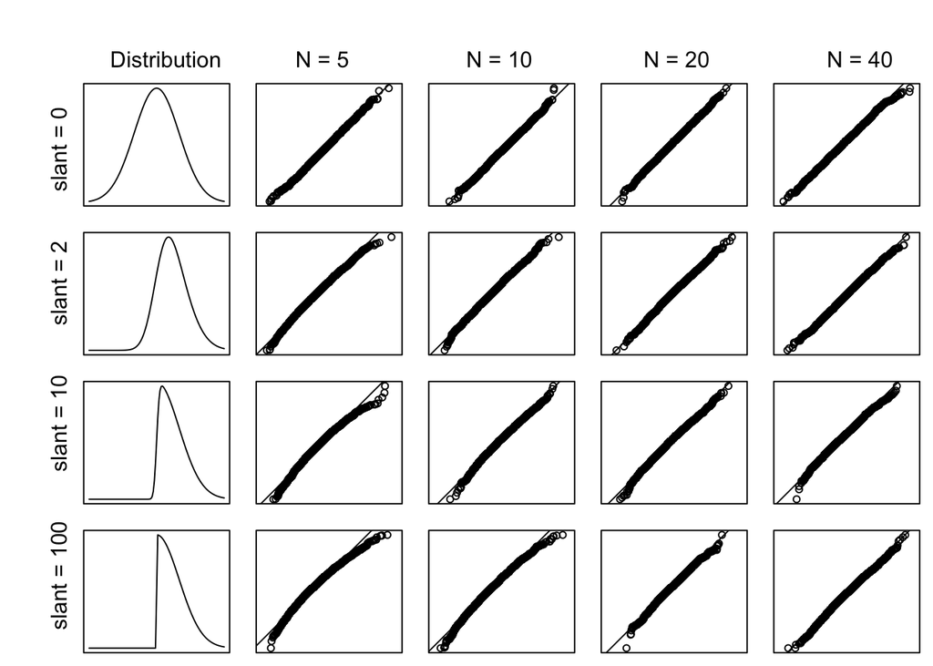

```r
x <- seq(from = -3, to = 3, by = 0.05)

par(mfrow = c(4,5), mai=c(0.1,0.1,0.1,0.1), oma = c(0, 4, 4, 0))

for(s in slant){
  plot(dsn(x, omega = sc, xi = loc, alpha = s), type = "l", axes = FALSE, frame.plot=TRUE)
  for(n in N){
    generate_qq(slant = s, N = n)
  }
}
mtext('slant = 100        slant = 10        slant = 2        slant = 0'
      , side = 2, outer = TRUE)
mtext('Distribution            N = 5                   N = 10                  N = 20                   N = 40'
      , side = 3, outer = TRUE)
```

```r
dev.copy(png, "plot.png", , width=500, height=350)
```

```r
dev.off()
```

# IV. Result Intepretation

We can see that the CLT is more accurate when slant is smaller (so that the distribution is more similar to a normal distribution). For each slant, when N gets larger, the estimation is more precise (look at the graph at the bottom right). Generally, we want our slant to be small, if that’s not the case, we need large sample size N to ensure relative accurate approximation.